# Covid Trends Take Home Exam

Woods, Stephen

12/05/2021

```r
#install tinytex for pdf output
#tinytex::install_tinytex()

# load initial packages


library(dplyr)
library(flux)
library(ggplot2)
library(gridExtra)
library(knitr)
library(rockchalk)
library(tidyverse)
library(ggthemes)
library(ggpubr)
library(RColorBrewer)

# read in static csv

mydata <- read.csv("covid.csv", sep = ",", stringsAsFactors = TRUE)

# see basic elements of data

str(mydata)
```

```
## 'data.frame':    61900 obs. of  12 variables:
##  $ dateRep                                                   : Factor w/ 350 levels "01/01/2020","01/02/2020",..: 168 156 144 132 120 108 96 84 72 60 ...
##  $ day                                                       : int  14 13 12 11 10 9 8 7 6 5 ...
##  $ month                                                     : int  12 12 12 12 12 12 12 12 12 12 ...
##  $ year                                                      : int  2020 2020 2020 2020 2020 2020 2020 2020 2020 2020 ...
##  $ cases                                                     : int  746 298 113 63 202 135 200 210 234 235 ...
##  $ deaths                                                    : int  6 9 11 10 16 13 6 26 10 18 ...
##  $ countriesAndTerritories                                   : Factor w/ 214 levels "Afghanistan",..: 1 1 1 1 1 1 1 1 1 1 ...
##  $ geoId                                                     : Factor w/ 213 levels "AD","AE","AF",..: 3 3 3 3 3 3 3 3 3 3 ...
##  $ countryterritoryCode                                      : Factor w/ 213 levels "","ABW","AFG",..: 3 3 3 3 3 3 3 3 3 3 ...
##  $ popData2019                                               : int  38041757 38041757 38041757 38041757 38041757 38041757 38041757 38041757 38041757 38041757 ...
##  $ continentExp                                              : Factor w/ 6 levels "Africa","America",..: 3 3 3 3 3 3 3 3 3 3 ...
##  $ Cumulative_number_for_14_days_of_COVID.19_cases_per_100000: num  9.01 7.05 6.87 7.13 6.97 ...
```

```r
head(mydata)
```

|  | dateRep | day | month | year | cases | deaths | countriesAndTerritories | geoId | countryterritoryCode | popData2019 | continentExp | Cumulative_number_for_14_days_of_COVID.19_cases_per_100000 |
| --- | --- | --- | --- | --- | --- | --- | --- | --- | --- | --- | --- | --- |
| 1 | 14/12/2020 | 14 | 12 | 2020 | 746 | 6 | Afghanistan | AF | AFG | 38041757 | Asia | 9.013779 |
| 2 | 13/12/2020 | 13 | 12 | 2020 | 298 | 9 | Afghanistan | AF | AFG | 38041757 | Asia | 7.052776 |
| 3 | 12/12/2020 | 12 | 12 | 2020 | 113 | 11 | Afghanistan | AF | AFG | 38041757 | Asia | 6.868768 |
| 4 | 11/12/2020 | 11 | 12 | 2020 | 63 | 10 | Afghanistan | AF | AFG | 38041757 | Asia | 7.134266 |
| 5 | 10/12/2020 | 10 | 12 | 2020 | 202 | 16 | Afghanistan | AF | AFG | 38041757 | Asia | 6.968658 |
| 6 | 09/12/2020 | 9 | 12 | 2020 | 135 | 13 | Afghanistan | AF | AFG | 38041757 | Asia | 6.963401 |

```r
max(mydata$year)
```

```
## [1] 2020
```

```r
min(mydata$year)
```

```
## [1] 2019
```

```r
#rename cumulative cases column

names(mydata)[names(mydata) == "Cumulative_number_for_14_days_of_COVID.19_cases_per_100000"] <- "cum_cases"


#add a month/year column
mydata$Month_Yr <- format(as.Date(mydata$dateRep, format = "%d/%m/%y"), "%m/%y")

#add a case rate column
mydata$case_rate <- mydata$cases/mydata$popData2019*100000
mydata$death_rate <- mydata$deaths/mydata$popData2019*100000
mydata$death_case_rate <- mydata$deaths/mydata$cases

head(mydata)
```

|  | dateRep | day | month | year | cases | deaths | countriesAndTerritories | geoId | countryterritoryCode | popData2019 | continentExp | cum_cases | Month_Yr | case_rate | death_rate | death_case_rate |
| --- | --- | --- | --- | --- | --- | --- | --- | --- | --- | --- | --- | --- | --- | --- | --- | --- |
| 1 | 14/12/2020 | 14 | 12 | 2020 | 746 | 6 | Afghanistan | AF | AFG | 38041757 | Asia | 9.013779 | 12/20 | 1.9610030 | 0.01577214 | 0.008042895 |
| 2 | 13/12/2020 | 13 | 12 | 2020 | 298 | 9 | Afghanistan | AF | AFG | 38041757 | Asia | 7.052776 | 12/20 | 0.7833497 | 0.02365821 | 0.030201342 |
| 3 | 12/12/2020 | 12 | 12 | 2020 | 113 | 11 | Afghanistan | AF | AFG | 38041757 | Asia | 6.868768 | 12/20 | 0.2970420 | 0.02891559 | 0.097345133 |
| 4 | 11/12/2020 | 11 | 12 | 2020 | 63 | 10 | Afghanistan | AF | AFG | 38041757 | Asia | 7.134266 | 12/20 | 0.1656075 | 0.02628690 | 0.158730159 |
| 5 | 10/12/2020 | 10 | 12 | 2020 | 202 | 16 | Afghanistan | AF | AFG | 38041757 | Asia | 6.968658 | 12/20 | 0.5309955 | 0.04205905 | 0.079207921 |
| 6 | 09/12/2020 | 9 | 12 | 2020 | 135 | 13 | Afghanistan | AF | AFG | 38041757 | Asia | 6.963401 | 12/20 | 0.3548732 | 0.03417297 | 0.096296296 |

```r
cols <- c("cases", "deaths", "cum_cases", "case_rate", "death_rate", "death_case_rate")

summary(mydata[cols])
```

```
##      cases            deaths           cum_cases           case_rate
##  Min.   : -8261   Min.   :-1918.00   Min.   :-147.4196   Min.   :-225.6090
##  1st Qu.:     0   1st Qu.:    0.00   1st Qu.:   0.7575   1st Qu.:   0.0000
##  Median :    15   Median :    0.00   Median :   6.7240   Median :   0.2604
##  Mean   :  1155   Mean   :   26.05   Mean   :  66.3206   Mean   :   4.8410
##  3rd Qu.:   273   3rd Qu.:    4.00   3rd Qu.:  52.5727   3rd Qu.:   3.1235
##  Max.   :234633   Max.   : 4928.00   Max.   :1900.8362   Max.   : 858.8957
##                                      NA's   :2879        NA's   :123
##    death_rate       death_case_rate
##  Min.   :-6.90477   Min.   :-1.869
##  1st Qu.: 0.00000   1st Qu.: 0.000
##  Median : 0.00000   Median : 0.008
##  Mean   : 0.08211   Mean   :   Inf
##  3rd Qu.: 0.03424   3rd Qu.: 0.028
##  Max.   :21.87219   Max.   :   Inf
##  NA's   :123        NA's   :19167
```

*Summaries of cases and deaths show negative case counts, which should be removed for regression analysis if present for selected country.*

*#### Section 1: Descriptive Statistics: Do an Exploratory Data Analysis (EDA) and provide appropriate summary statistics / visualizations to help understand the spread of the disease (incidence) as well as its fatality rate. (5 points) ####*

(1)(a) See total deaths and cases by continent and month.

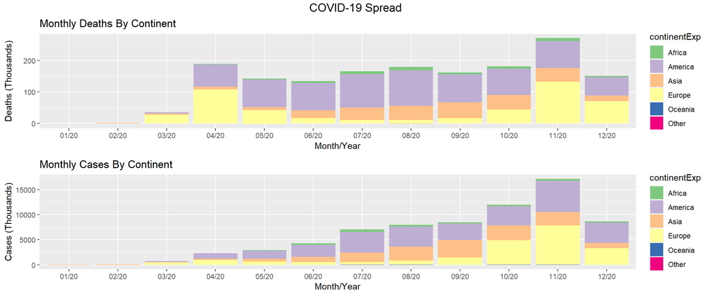

```r
#Get an idea of total deaths by continent over time.


col1 <- ggplot(data = mydata, aes(x = Month_Yr, y = deaths/1000, fill = continentExp)) +
  geom_col() +
  scale_fill_brewer(palette = "Accent") +
  ggtitle("Monthly Deaths By Continent") +
  ylab("Deaths (Thousands)") + xlab("Month/Year")+
  theme(legend.position = c(), legend.background = element_rect())

col2 <- ggplot(data = mydata, aes(x = Month_Yr, y = cases/1000, fill = continentExp)) +
  geom_col() +
  scale_fill_brewer(palette = "Accent") +
  ggtitle("Monthly Cases By Continent") +
  ylab("Cases (Thousands)") + xlab("Month/Year")+
  theme(legend.position = c(), legend.background = element_rect())


figure <- ggarrange(col1, col2,
          font.label = list(size = 10),
          #vjust = .3,
          #hjust = -1.2,
          ncol = 1, nrow = 2,
          align = "v")

annotate_figure(figure,
               top = text_grob("COVID-19 Spread", size = 14))
```

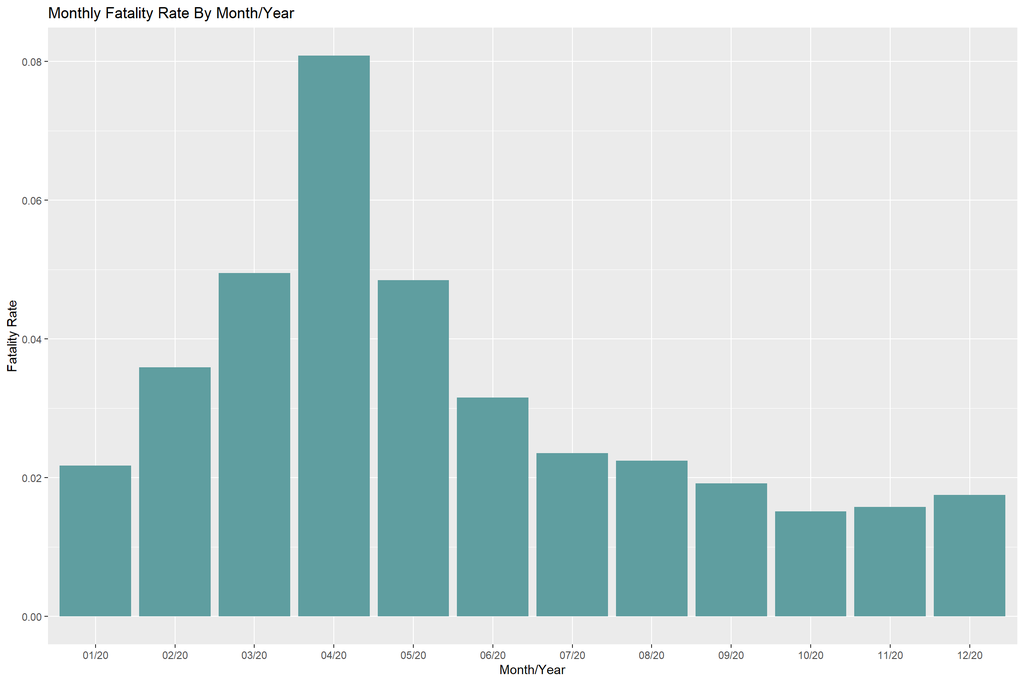

```r
#get total deaths by Month_Year

monthly_deaths <- aggregate(cbind(cases,deaths) ~ Month_Yr, mydata, sum)
monthly_df <- as.data.frame(monthly_deaths)

#define fatality rate as new deaths divided by new cases
monthly_df$fatality <- monthly_df$deaths/monthly_df$cases


#look at total monthly fatality rate

fatality1 <- ggplot(data = monthly_df) + aes(x = Month_Yr, y = fatality) +
    geom_col(fill = "cadetblue") + ggtitle("Monthly Fatality Rate By Month/Year") +
    ylab("Fatality Rate") + xlab("Month/Year")+
    theme(legend.position = c(), legend.background = element_rect())

fatality1
```

*(World wide fatality rate peaks around 8% in April 2020 and declines to around 2% from July 2020 through December 2020.)*

(1)(c) Look at the distribution of cases with qq plots and box plots.

```r
par(mfrow = c(2,1))

qqnorm(mydata$cases, col = "indianred", main = "Case Distribution", xlab = "theoretical", ylab = "sample")
qqline(mydata$cases)


skewness(mydata$cases)
```

```
## [1] 15.86973
```

```r
kurtosis(mydata$cases)
```

```
## [1] 364.2164
```

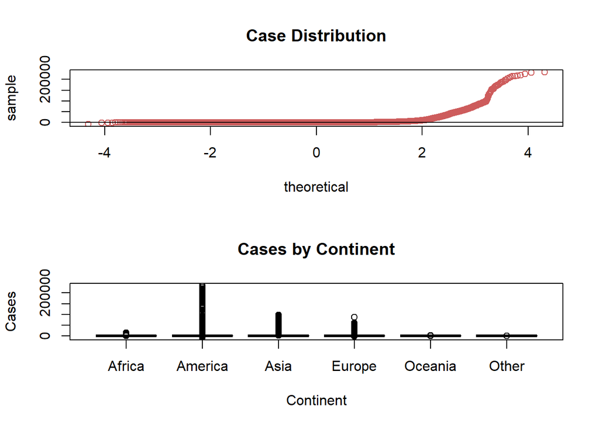

```r
boxplot(mydata$cases ~ mydata$continentExp, col = "cadetblue", main = "Cases by Continent", xlab = "Continent", ylab = "Cases")
```

*(With time series data, it makes sense that there are many outliers and data does not resemble a normal distribution)*

2)Inferential Statistics: Pick 2 countries and compare their incidence and fatality rates using hypothesis testing and confidence interval methods

```r
#look at cases and deaths by country to compare countries with a similar magnitude of cases:

country_deaths <- aggregate(cbind(cases,deaths) ~ countryterritoryCode, mydata, sum)
country_df <- as.data.frame(country_deaths)

head(country_df[order(country_df$cases, decreasing = TRUE), ])
```

|  | countryterritoryCode | cases | deaths |
| --- | --- | --- | --- |
| 200 | USA | 16256754 | 299177 |
| 93 | IND | 9884100 | 143355 |
| 29 | BRA | 6901952 | 181402 |
| 165 | RUS | 2653928 | 46941 |
| 69 | FRA | 2376852 | 57911 |
| 72 | GBR | 1849403 | 64170 |

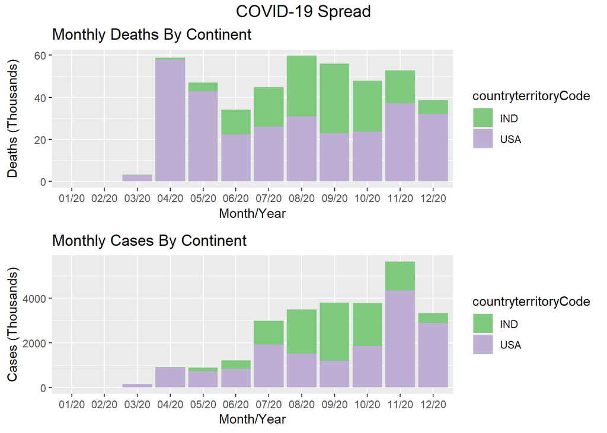

```r
mydata_2 <- subset(mydata, countryterritoryCode == "USA" | countryterritoryCode == "IND")


# I am going to compare the United States and India. First I want to see an overview of the spread.
col3 <- ggplot(data = mydata_2, aes(x = Month_Yr, y = deaths/1000, fill = countryterritoryCode)) +
  geom_col() +
  scale_fill_brewer(palette = "Accent") +
  ggtitle("Monthly Deaths By Continent") +
  ylab("Deaths (Thousands)") + xlab("Month/Year")+
  theme(legend.position = c(), legend.background = element_rect())

col4 <- ggplot(data = mydata_2, aes(x = Month_Yr, y = cases/1000, fill = countryterritoryCode)) +
  geom_col() +
  scale_fill_brewer(palette = "Accent") +
  ggtitle("Monthly Cases By Continent") +
  ylab("Cases (Thousands)") + xlab("Month/Year")+
  theme(legend.position = c(), legend.background = element_rect())


figure <- ggarrange(col3, col4,
          font.label = list(size = 10),
          ncol = 1, nrow = 2,
          align = "v")

annotate_figure(figure,
               top = text_grob("COVID-19 Spread", size = 14))
```

(2)(a) compare their incidence and fatality rates using hypothesis testing and confidence interval methods

```r
# Subset data into dataframes for USA and India

head(mydata_2)
```

|  | dateRep | day | month | year | cases | deaths | countriesAndTerritories | geoId | countryterritoryCode | popData2019 | continentExp | cum_cases | Month_Yr | case_rate | death_rate | death_case_rate |
| --- | --- | --- | --- | --- | --- | --- | --- | --- | --- | --- | --- | --- | --- | --- | --- | --- |
| 26746 | 14/12/2020 | 14 | 12 | 2020 | 27071 | 336 | India | IN | IND | 1366417756 | Asia | 33.10913 | 12/20 | 1.981166 | 0.02458984 | 0.01241181 |
| 26747 | 13/12/2020 | 13 | 12 | 2020 | 30254 | 391 | India | IN | IND | 1366417756 | Asia | 33.96545 | 12/20 | 2.214111 | 0.02861497 | 0.01292391 |
| 26748 | 12/12/2020 | 12 | 12 | 2020 | 30006 | 442 | India | IN | IND | 1366417756 | Asia | 34.81117 | 12/20 | 2.195961 | 0.03234735 | 0.01473039 |
| 26749 | 11/12/2020 | 11 | 12 | 2020 | 29398 | 414 | India | IN | IND | 1366417756 | Asia | 35.63932 | 12/20 | 2.151465 | 0.03029820 | 0.01408259 |
| 26750 | 10/12/2020 | 10 | 12 | 2020 | 31521 | 412 | India | IN | IND | 1366417756 | Asia | 36.64077 | 12/20 | 2.306835 | 0.03015183 | 0.01307065 |
| 26751 | 09/12/2020 | 9 | 12 | 2020 | 32080 | 402 | India | IN | IND | 1366417756 | Asia | 37.58982 | 12/20 | 2.347745 | 0.02941999 | 0.01253117 |

```r
mydata_USA <- subset(mydata, countryterritoryCode == "USA")
mydata_IND <- subset(mydata, countryterritoryCode == "IND")

#Determine if there is a significant difference in mean death rate between USA and India

t.test(mydata_USA$death_rate, mydata_IND$death_rate, alternative = "two.sided", conf.level = 0.95, var.equal = FALSE)
```

```
##
##  Welch Two Sample t-test
##
## data:  mydata_USA$death_rate and mydata_IND$death_rate
## t = 18.359, df = 360.15, p-value < 2.2e-16
## alternative hypothesis: true difference in means is not equal to 0
## 95 percent confidence interval:
##  0.2050974 0.2543081
## sample estimates:
##  mean of x  mean of y
## 0.25976377 0.03006103
```

```r
#Determine if there is a significant difference in mean case rate between USA and India

t.test(mydata_USA$case_rate, mydata_IND$case_rate, alternative = "two.sided", conf.level = 0.95, var.equal = FALSE)
```

```
##
##  Welch Two Sample t-test
##
## data:  mydata_USA$case_rate and mydata_IND$case_rate
## t = 14.158, df = 362.78, p-value < 2.2e-16
## alternative hypothesis: true difference in means is not equal to 0
## 95 percent confidence interval:
##  10.36974 13.71515
## sample estimates:
## mean of x mean of y
## 14.115108  2.072661
```

```r
#Determine if there is a significant difference in mean death_case_rate (new deaths/new cases) between USA and India

t.test(mydata_USA$death_case_rate, mydata_IND$death_case_rate, alternative = "two.sided", conf.level = 0.95, var.equal = FALSE)
```

```
##
##  Welch Two Sample t-test
##
## data:  mydata_USA$death_case_rate and mydata_IND$death_case_rate
## t = 2.3714, df = 592.81, p-value = 0.01804
## alternative hypothesis: true difference in means is not equal to 0
## 95 percent confidence interval:
##  0.001098985 0.011695363
## sample estimates:
##  mean of x  mean of y
## 0.02762786 0.02123069
```

3. Correlation: Pick all the countries and evaluate the relationship between incidence rates and fatality rates. Compute the correlation coefficient, if relevant.

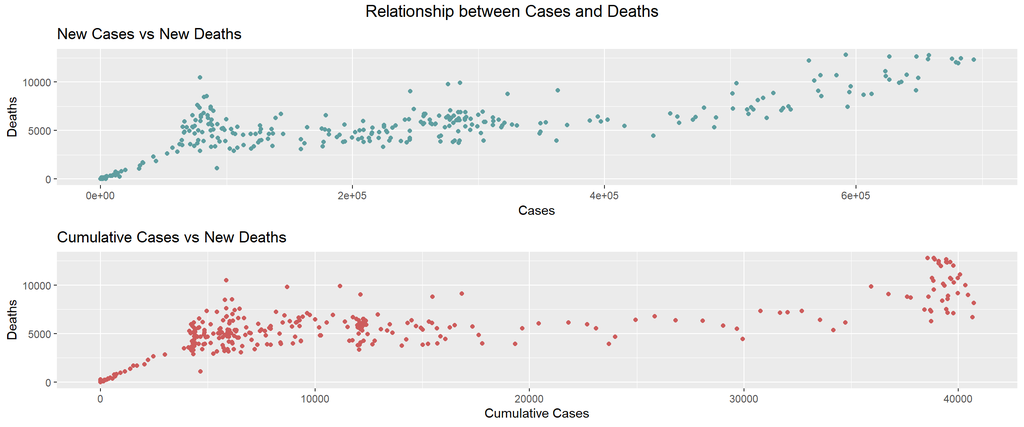

```r
# create a data frame containing total metrics by day


daily_data <- aggregate(cbind(cases, cum_cases, deaths) ~ dateRep, mydata, sum)
daily_df <- as.data.frame(daily_data)
daily_df$fatality <- daily_df$deaths/daily_df$cases

#look at a scatter plot between cases and deaths

point1 <- ggplot(data = daily_df) + aes(x = cases, y = deaths) +
    geom_point(color = "cadetblue") + ggtitle("New Cases vs New Deaths") +
    ylab("Deaths") + xlab("Cases")+
    theme(legend.position = c(), legend.background = element_rect())

point2 <- ggplot(data = daily_df) + aes(x = cum_cases, y = deaths) +
    geom_point(color = "indianred") + ggtitle("Cumulative Cases vs New Deaths") +
    ylab("Deaths") + xlab("Cumulative Cases")+
    theme(legend.position = c(), legend.background = element_rect())

figure <- ggarrange(point1, point2,
          font.label = list(size = 10),
          ncol = 1, nrow = 2,
          align = "v")

annotate_figure(figure,
               top = text_grob("Relationship between Cases and Deaths", size = 14))
```

*(There is a moderate positive correlation between new cases and new deaths and cumulative cases and new deaths. I do not see much of a visual difference between the two charts.)*

(3)(b) Get log 10 transformations of columns and see if that reveals a better relationship and generate a correlation matrix plot.

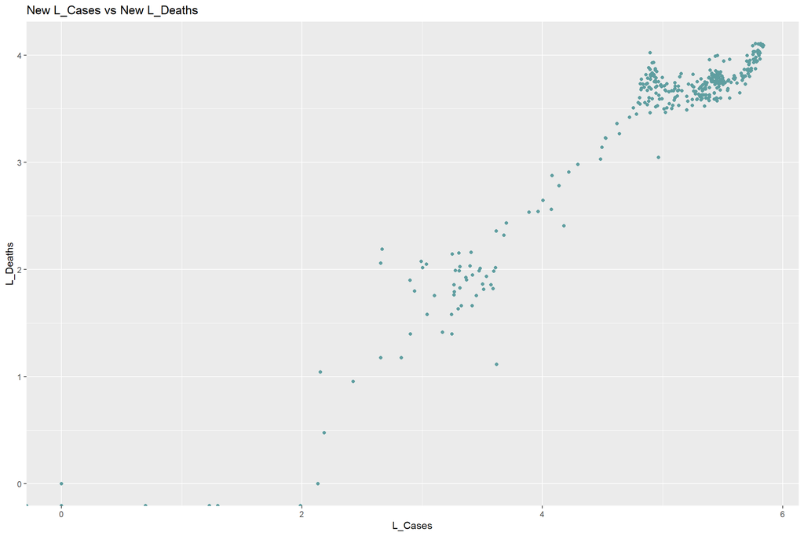

```r
daily_df$L_cases <- log10(daily_df$cases)
daily_df$L_deaths <- log10(daily_df$deaths)



ggplot(data = daily_df) + aes(x = L_cases, y = L_deaths) +
    geom_point(color = "cadetblue") + ggtitle("New L_Cases vs New L_Deaths") +
    ylab("L_Deaths") + xlab("L_Cases")+
    theme(legend.position = c(), legend.background = element_rect())
```

```r
library(corrplot)
cols2 <- c("cases", "deaths", "L_cases", "L_deaths", "cum_cases")

corr_mat <- cor(daily_df[cols2], method = "s")

corr_mat
```

```
##               cases    deaths   L_cases  L_deaths cum_cases
## cases     1.0000000 0.7964453 1.0000000 0.7964453 0.9751182
## deaths    0.7964453 1.0000000 0.7964453 1.0000000 0.7895876
## L_cases   1.0000000 0.7964453 1.0000000 0.7964453 0.9751182
## L_deaths  0.7964453 1.0000000 0.7964453 1.0000000 0.7895876
## cum_cases 0.9751182 0.7895876 0.9751182 0.7895876 1.0000000
```

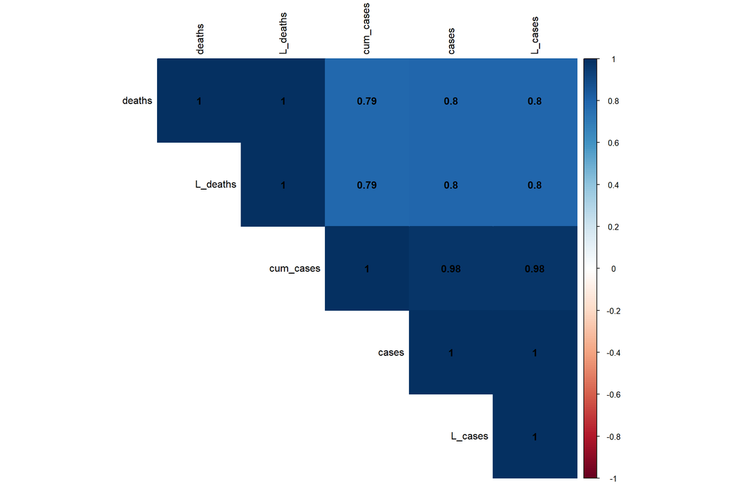

```r
library("corrplot")
corrplot(corr_mat, method = "color",
     type = "upper", order = "hclust",
     addCoef.col = "black",
     tl.col = "black")
```

*(There is a moderately strong correlation of 0.8 between both cases and deaths and L_cases and L_deaths. Log ten transformations do not appear to add anything, so will not be considered in further analysis. There is a correlation of .98 between cum_cases and cases, which makes sense as they are different metrics reporting on the same variable.)*

4. Regression: Pick United States. Look at the time series of cases and time series of deaths. Use a regression model to predict the number of cases and the number of deaths for the next 5 days in the future.

```r
library(lubridate)  # widely used for handling dates
library(tidyverse) # loads a group of 'tidyverse' packages, including dplyr, which define mutate() and filter() functions

# Filter for only U.S. and change dateRep to date type.

covid_US <- mydata %>%
  mutate(dateRep = dmy(dateRep)) %>%
  filter(countryterritoryCode == "USA") %>%
  arrange(dateRep)

countdays <- c(1:350)

covid_US$countdays <- countdays

tail(covid_US)
```

|  | dateRep | day | month | year | cases | deaths | countriesAndTerritories | geoId | countryterritoryCode | popData2019 | continentExp | cum_cases | Month_Yr | case_rate | death_rate | death_case_rate | countdays |
| --- | --- | --- | --- | --- | --- | --- | --- | --- | --- | --- | --- | --- | --- | --- | --- | --- | --- |
| 345 | 2020-12-09 | 9 | 12 | 2020 | 217344 | 2564 | United_States_of_America | US | USA | 329064917 | America | 784.1951 | 12/20 | 66.04897 | 0.7791776 | 0.011796967 | 345 |
| 346 | 2020-12-10 | 10 | 12 | 2020 | 220025 | 3124 | United_States_of_America | US | USA | 329064917 | America | 794.3560 | 12/20 | 66.86371 | 0.9493567 | 0.014198387 | 346 |
| 347 | 2020-12-11 | 11 | 12 | 2020 | 224680 | 2748 | United_States_of_America | US | USA | 329064917 | America | 830.3942 | 12/20 | 68.27832 | 0.8350936 | 0.012230728 | 347 |
| 348 | 2020-12-12 | 12 | 12 | 2020 | 234633 | 3343 | United_States_of_America | US | USA | 329064917 | America | 838.5142 | 12/20 | 71.30295 | 1.0159090 | 0.014247783 | 348 |
| 349 | 2020-12-13 | 13 | 12 | 2020 | 216017 | 2315 | United_States_of_America | US | USA | 329064917 | America | 857.0892 | 12/20 | 65.64571 | 0.7035086 | 0.010716749 | 349 |
| 350 | 2020-12-14 | 14 | 12 | 2020 | 189723 | 1340 | United_States_of_America | US | USA | 329064917 | America | 873.2116 | 12/20 | 57.65519 | 0.4072145 | 0.007062929 | 350 |

```r
# Look at different models for predicting deaths using case data

#summary(lr_md1.1 <- lm(deaths ~ cases*dateRep*month, data = covid_US))

# Look at different models for predicting deaths using case data

#summary(lr_md1.2 <- lm(deaths ~ cases, data = covid_US))

# Look at different models for predicting deaths using case data

summary(lr_md1.3 <- lm(deaths ~ as.factor(month)*countdays+cases, data = covid_US))
```

```
##
## Call:
## lm(formula = deaths ~ as.factor(month) * countdays + cases, data = covid_US)
##
## Residuals:
##     Min      1Q  Median      3Q     Max
## -1102.3  -169.3     0.0   114.7  2964.8
##
## Coefficients:
##                                Estimate Std. Error t value Pr(>|t|)
## (Intercept)                   4.110e-03  1.418e+02   0.000 0.999977
## as.factor(month)2             1.273e-01  4.145e+02   0.000 0.999755
## as.factor(month)3            -1.505e+02  5.973e+02  -0.252 0.801174
## as.factor(month)4            -2.764e+03  8.517e+02  -3.245 0.001298 **
## as.factor(month)5             4.724e+03  1.037e+03   4.557 7.35e-06 ***
## as.factor(month)6             3.736e+03  1.333e+03   2.802 0.005384 **
## as.factor(month)7            -1.560e+03  1.482e+03  -1.052 0.293512
## as.factor(month)8            -3.898e+02  1.747e+03  -0.223 0.823568
## as.factor(month)9             2.540e+03  2.026e+03   1.253 0.210980
## as.factor(month)10            5.762e+03  2.272e+03   2.536 0.011680 *
## as.factor(month)11            7.062e+03  2.954e+03   2.391 0.017368 *
## as.factor(month)12            2.216e+01  3.947e+02   0.056 0.955254
## countdays                    -4.439e-04  7.382e+00   0.000 0.999952
## cases                         1.776e-02  2.011e-03   8.829  < 2e-16 ***
## as.factor(month)2:countdays  -3.134e-03  1.100e+01   0.000 0.999773
## as.factor(month)3:countdays   2.059e+00  1.053e+01   0.196 0.845082
## as.factor(month)4:countdays   3.881e+01  1.071e+01   3.625 0.000336 ***
## as.factor(month)5:countdays  -2.726e+01  1.045e+01  -2.608 0.009518 **
## as.factor(month)6:countdays  -2.063e+01  1.082e+01  -1.906 0.057579 .
## as.factor(month)7:countdays   6.559e+00  1.051e+01   0.624 0.533088
## as.factor(month)8:countdays   2.302e+00  1.051e+01   0.219 0.826807
## as.factor(month)9:countdays  -9.528e+00  1.072e+01  -0.889 0.374560
## as.factor(month)10:countdays -2.083e+01  1.083e+01  -1.922 0.055466 .
## as.factor(month)11:countdays -2.610e+01  1.218e+01  -2.143 0.032888 *
## as.factor(month)12:countdays -3.960e+00  7.563e+00  -0.524 0.600871
## ---
## Signif. codes:  0 '***' 0.001 '**' 0.01 '*' 0.05 '.' 0.1 ' ' 1
##
## Residual standard error: 367.6 on 325 degrees of freedom
## Multiple R-squared:  0.7845, Adjusted R-squared:  0.7686
## F-statistic:  49.3 on 24 and 325 DF,  p-value: < 2.2e-16
```

```r
 #best performing

# Look at different models for predicting deaths using cum_case data

#summary(lr_md1.4 <- lm(deaths ~ cum_cases*dateRep*month, data = covid_US))


# Look at different models for predicting cases
summary(lr_md2 <- lm(cases ~ as.factor(month)*countdays, data = covid_US))
```

```
##
## Call:
## lm(formula = cases ~ as.factor(month) * countdays, data = covid_US)
##
## Residuals:
##    Min     1Q Median     3Q    Max
## -71638  -3145      0   3326  44613
##
## Coefficients:
##                                Estimate Std. Error t value Pr(>|t|)
## (Intercept)                  -2.314e-01  3.905e+03   0.000  0.99995
## as.factor(month)2            -7.169e+00  1.141e+04  -0.001  0.99950
## as.factor(month)3            -4.775e+04  1.623e+04  -2.941  0.00350 **
## as.factor(month)4             3.824e+04  2.336e+04   1.637  0.10258
## as.factor(month)5             5.555e+04  2.838e+04   1.957  0.05118 .
## as.factor(month)6            -1.061e+05  3.624e+04  -2.929  0.00365 **
## as.factor(month)7            -6.067e+04  4.068e+04  -1.491  0.13681
## as.factor(month)8             1.886e+05  4.695e+04   4.016 7.35e-05 ***
## as.factor(month)9            -1.742e+04  5.579e+04  -0.312  0.75508
## as.factor(month)10           -3.596e+05  5.931e+04  -6.063 3.70e-09 ***
## as.factor(month)11           -7.836e+05  6.879e+04 -11.392  < 2e-16 ***
## as.factor(month)12           -1.863e+03  1.087e+04  -0.171  0.86404
## countdays                     2.500e-02  2.033e+02   0.000  0.99990
## as.factor(month)2:countdays   1.765e-01  3.030e+02   0.001  0.99954
## as.factor(month)3:countdays   6.891e+02  2.875e+02   2.397  0.01709 *
## as.factor(month)4:countdays  -8.432e+01  2.948e+02  -0.286  0.77505
## as.factor(month)5:countdays  -2.318e+02  2.875e+02  -0.806  0.42067
## as.factor(month)6:countdays   7.920e+02  2.948e+02   2.687  0.00759 **
## as.factor(month)7:countdays   6.136e+02  2.875e+02   2.134  0.03356 *
## as.factor(month)8:countdays  -6.092e+02  2.875e+02  -2.119  0.03485 *
## as.factor(month)9:countdays   2.196e+02  2.948e+02   0.745  0.45686
## as.factor(month)10:countdays  1.441e+03  2.875e+02   5.014 8.77e-07 ***
## as.factor(month)11:countdays  2.887e+03  2.948e+02   9.792  < 2e-16 ***
## as.factor(month)12:countdays  6.032e+02  2.056e+02   2.934  0.00358 **
## ---
## Signif. codes:  0 '***' 0.001 '**' 0.01 '*' 0.05 '.' 0.1 ' ' 1
##
## Residual standard error: 10120 on 326 degrees of freedom
## Multiple R-squared:  0.9644, Adjusted R-squared:  0.9619
## F-statistic:   384 on 23 and 326 DF,  p-value: < 2.2e-16
```

```r
  #best performing
```

*(Models with the highest Adjusted R-squared values were selected. For predicting deaths, lr_md1.3 had the highest adjusted R-squared value of .7686, indicating that the variables month (factored), count days (count of days since pandemic began), the interaction between factored month and countdays, and case count can explain 76.86% of the variation in deaths. The cases variable shows strong prediction value, with a high t value and strong significance. For predicting cases, a model using factored month, countdays, and the interaction of month and countdays can explain 96.19% of the variance in new cases.)*

(4)(a) Plot out residuals of death predicting model

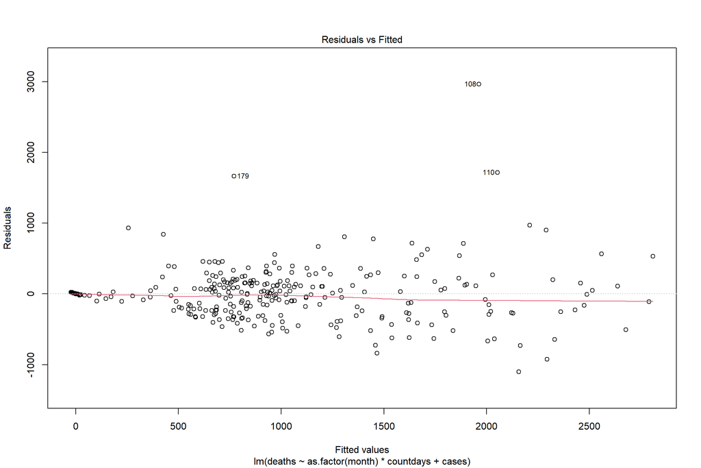

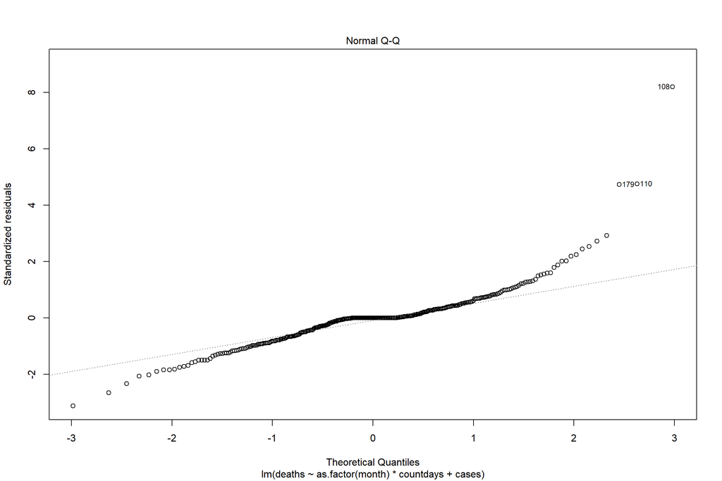

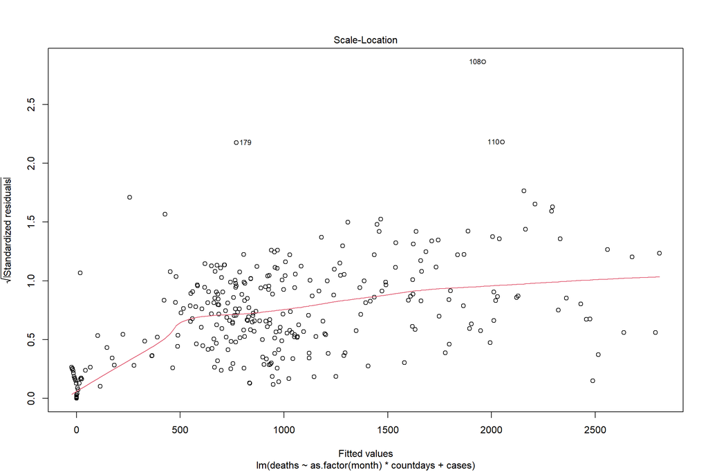

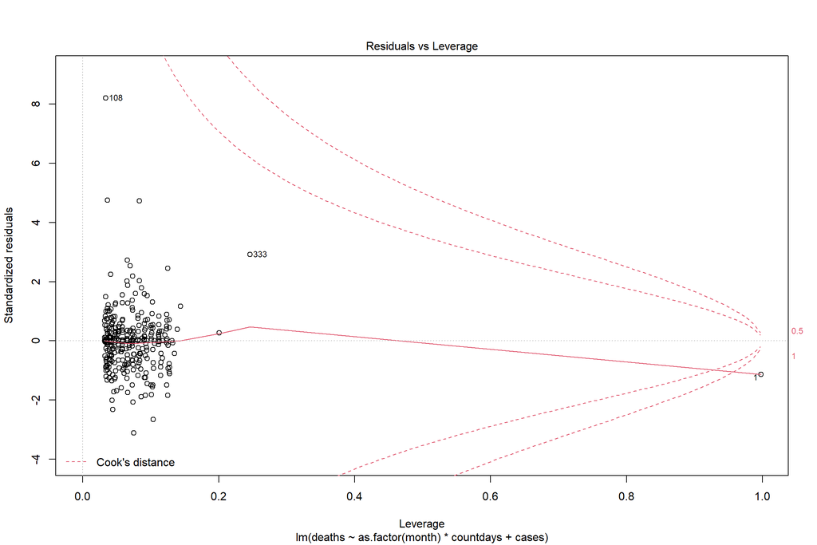

```r
plot(lr_md1.3)
```

*(For the death prediction model, while residuals are grouped around various points, they do not follow a clear trend)*

(4)(b) Plot out residuals of case predicting model

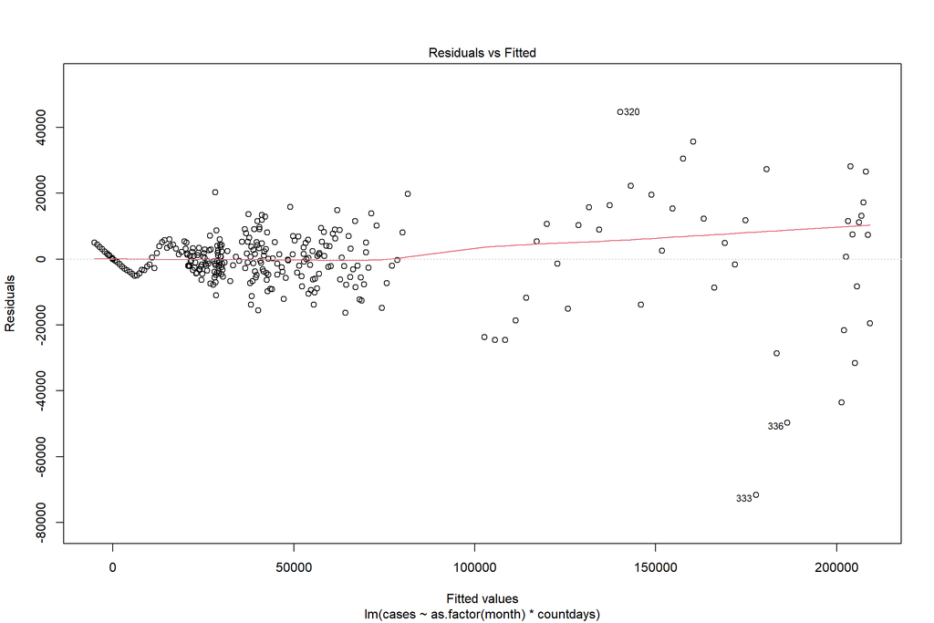

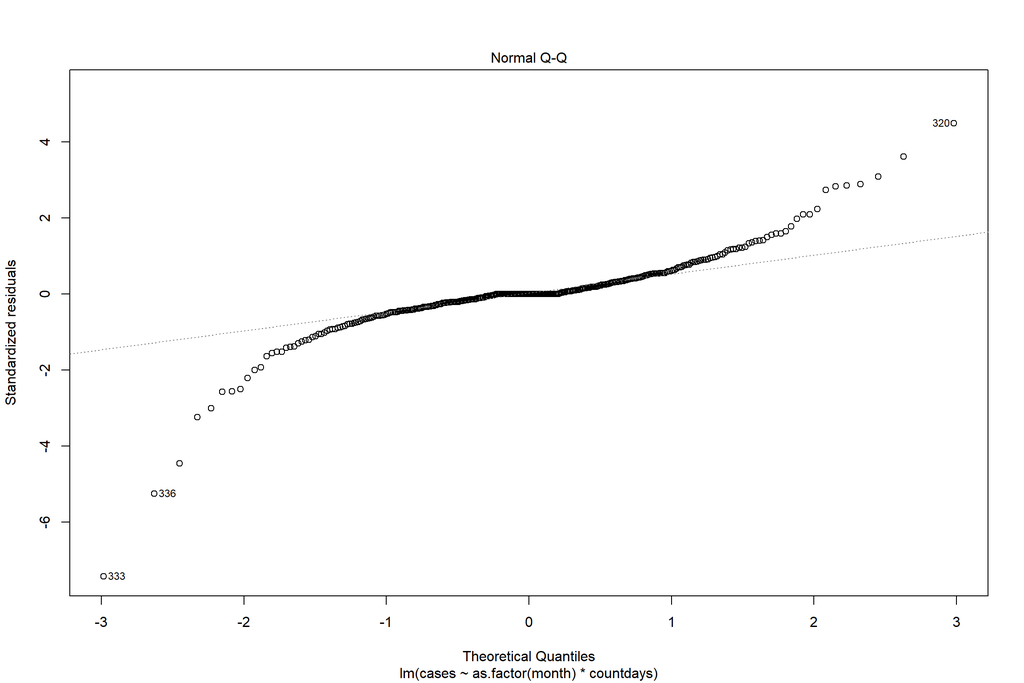

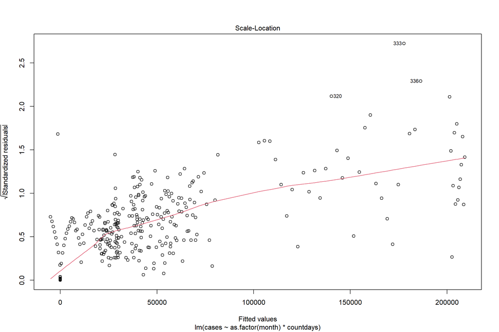

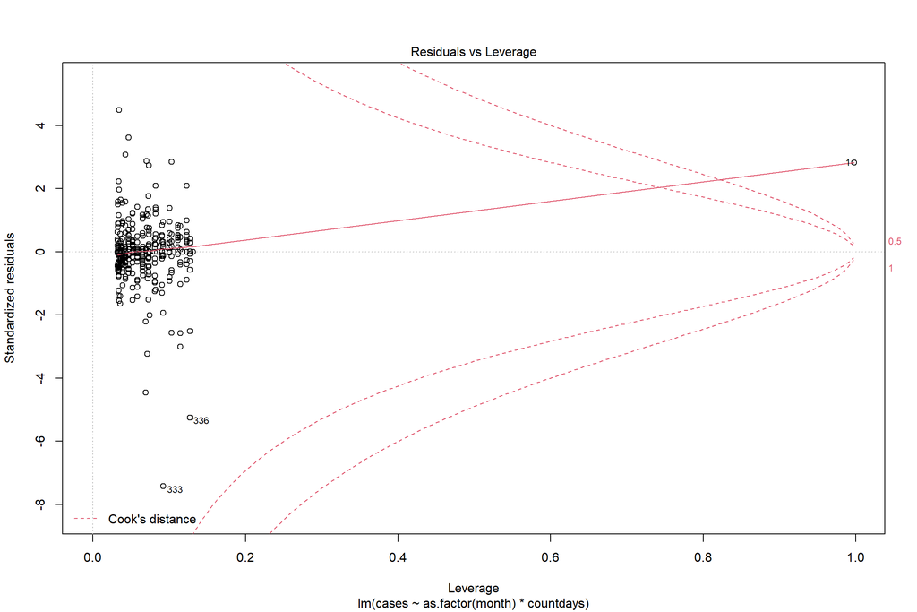

```r
plot(lr_md2)
```

*(For the case prediction model, the residuals vs fitted plot does suggest that residuals do not follow a constant variance. As fitted values increase, magnitude of residuals increase.)*

(4)(c.1) Predict cases for the next five days.

```r
month <- c(12,12,12,12,12)
countdays <- c(351,352,353,354,355)



case_df <- data.frame(month, countdays)



case_model <- predict(lr_md2, newdata = case_df, interval = "prediction", level = 0.95)

case_model <- data.frame(month, countdays, case_model)

case_model
```

|  | month | countdays | fit | lwr | upr |
| --- | --- | --- | --- | --- | --- |
| 1 | 12 | 351 | 209859.2 | 189210.6 | 230507.7 |
| 2 | 12 | 352 | 210462.4 | 189808.4 | 231116.3 |
| 3 | 12 | 353 | 211065.5 | 190406.1 | 231725.0 |
| 4 | 12 | 354 | 211668.7 | 191003.5 | 232334.0 |
| 5 | 12 | 355 | 212271.9 | 191600.8 | 232943.1 |

(4)(c.2) Predict deaths for the next five days.

```r
#use predicted cases from model above as an input for the cases predictor for my death model
cases <- unlist(case_model[3])


death_df <- data.frame(month, countdays, cases)


death_model <- predict(lr_md1.3, newdata = death_df, interval = "prediction", level = 0.95)

#combine both models into a final output/prediction model for the next five days

predict_model <- data.frame(case_model, death_model)

colnames(predict_model) <- c("month", "countdays", "cases", "casesLWR", "casesUPR", "deaths", "deathsLWR", "deathsUPR")

round(predict_model,0)
```

|  | month | countdays | cases | casesLWR | casesUPR | deaths | deathsLWR | deathsUPR |
| --- | --- | --- | --- | --- | --- | --- | --- | --- |
| 1 | 12 | 351 | 209859 | 189211 | 230508 | 2358 | 1608 | 3108 |
| 2 | 12 | 352 | 210462 | 189808 | 231116 | 2365 | 1615 | 3115 |
| 3 | 12 | 353 | 211066 | 190406 | 231725 | 2372 | 1622 | 3122 |
| 4 | 12 | 354 | 211669 | 191004 | 232334 | 2379 | 1628 | 3129 |
| 5 | 12 | 355 | 212272 | 191601 | 232943 | 2385 | 1635 | 3136 |

*(Above shows predicted interval estimates for COVID-19 cases and deaths for days 351 through 355. This model is predicting around 210,000 new cases each day and 2,400 deaths each day. These levels are consistent with case and death volumes observed from days 340 to 350. Given factored month is one of the explanatory variables, it makes sense that predicted values for days within December are close to values last observed in December.)*

*(Overall, there is significant variability in COVID-19 cases and deaths. While we observed a correlation of .80 between new cases and new deaths, it was harder to develop a linear regression model that historically explained the variation in new deaths than it was for new cases. This was surprising as new cases or cumulative cases should be an indicator of future new deaths. My linear model of new deaths achieved an R-squared value of .7686 and my model of new cases achieved an R-squared value of 96.19.)*